# Hypothesis Testing & Probability

```r
library(tidyverse)
library(tidyverse)
library(infer)
library(janitor)
```

1.1

Q1

```r
data("msleep")

head(msleep)

glimpse(msleep)

rowSums(is.na(msleep))
```

Q2

Null Hypothesis: Mean sleep total in sampled population is 7hrs

Alternative Hypothesis: Mean sleep total in sampled population is not equal to 7hrs

CI: 5%

```r
observed_sleep_stat <- msleep %>%
  summarise(
    mean_sleep = mean(sleep_total)
  )
```

```r
null_distribution_msleep <- msleep %>%
  specify(response = sleep_total) %>%
  hypothesise(null = "point", mu = 7) %>%
  generate(reps = 10000, type = "bootstrap") %>%
  calculate(stat = "mean")
```

[figure not shown]

```r
(p_value_sleep <- null_distribution_msleep %>%
  get_pvalue(obs_stat = observed_sleep_stat,

             direction = "both"))
```

[output not shown]

The p-value is less than 5% therefore we can reject the null hypothesis as the mean sleep in the sampled population does not suggest most animals sleep for 7 hrs a night

Q3

Null Hypothesis: Mean sleep total is the same for omnivores and herbivores

Alternative Hypothesis: Mean sleep total in sampled population is significantly different between omnivores and herbivores

CI: 5%

```r
msleep %>%
  distinct(vore)
```

```r
msleep_vore <- msleep %>%
  filter(vore %in% c("omni", "herbi"))
```

```r
obs_vore_stat <- msleep_vore %>%
  specify(sleep_total ~ vore) %>%
  calculate(stat = "diff in means",
            order = c("omni",
                      "herbi"))
```

```r
null_dist_vore <- msleep_vore %>%
  specify(sleep_total ~ vore) %>%
  hypothesise(null = "independence") %>%
  generate(reps = 10000,
           type = "permute") %>%
  calculate(stat = "diff in means",
            order = c("omni",
                      "herbi"))
```

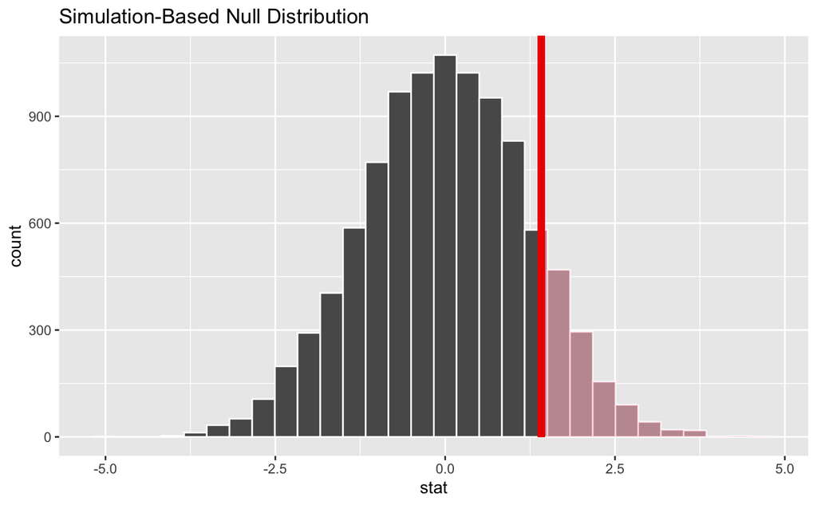

```r
null_dist_vore %>%
  visualise(bins = 30) +
  shade_pvalue(obs_stat = obs_vore_stat,
               direction = "greater")
```

[output not shown]

With a p-value of 0.12 we cant reject the null hypothesis, and so we can say the mean sleep for omnivores and herbivores is not significantly different

Q4

Null hypothesis: The proportion of domesticated animals in the population is 5%

Alternative hypothesis: The proportion of domesticated animals in the population is greater than 5%

CI: 5%

```r
msleep_domestic <- msleep %>%
  mutate(domesticated = case_when(
    conservation == "domesticated" ~ "Yes",
    TRUE ~ "No"
  ))
```

```r
domestic_prop <- msleep_domestic %>%
  summarise(prop =
    (sum(domesticated == "Yes"))/nrow(msleep_domestic)
  )
```

```r
null_dom_distribution <- msleep_domestic %>%
  specify(response = domesticated,
          success = "Yes") %>%
  hypothesise(null = "point",
              p = 0.05) %>%
  generate(reps = 30000,
           type = "draw") %>%
  calculate(stat = "prop")
```

```r
null_dom_distribution %>%
  visualise() +
  shade_pvalue(obs_stat = domestic_prop,
               direction = "greater")
```

[output not shown]

```r
null_dom_distribution %>%
  get_p_value(obs_stat = domestic_prop,
              direction = "greater")
```

[output not shown]

With a p-value of 0.008 and a CI of 5% we can reject the null hypothesis that 5% of the animals are domesticated, and can say that significantly more than 5% of animals in the sample are domesticated.

1.2

Q1

Null hypothesis: proportion of towns population who know about the coffee shop is 0.4

Alternative hypothesis: The proportion of people who know about the coffee shop is more than 0.4

We would use a draw method to generate the null distributiom

Q2

Null hypothesis: The position of the banner has no effect on click-through rate, and the click through rate is the same for both groups

Alternative hypothesis: One of the banner positions has a higgher CTR than the other

Use the draw method to generate the null distribution

Q3

Null hypothesis: The parts all meet the dimensions criteria

Alternative hypothesis: The parts do not all meet the dimensions criteria and have drifted

Use bootstrapping to generate the null distribution

1.3

Q1

The p-value is greater than the CI of 5%. This suggests that the proportion from the sample would be 7% likely to fall in the null-distribution. Therefore we can’t reject the null hypothesis.

Q2

The CI is greater than the p-value so we have to reject the null hypothesis as one of the banner shas a higher CTR than the other

Q3